# MSBA 265 Project Group 1

# Sentiment Analysis of Financial Statements

Performing sentiment analysis on financial statements can reveal the underlying sentiments in the text and help understand market trends and business performance at a glance.

## Introduction

Sentiment analysis is a key component in understanding the opinions behind the numbers in financial statements. It can give us insights into the market sentiment that could potentially impact stock prices and overall market trends.

## Importing Necessary Libraries

To start our analysis, we first need to import the required libraries. Here's what each library does for our project:

- `pandas`: Essential for data manipulation and analysis.
- `matplotlib.pyplot` & `seaborn`: Used for data visualization.
- `WordCloud`: Helps in visual representation of text data, highlighting the most frequent words in a graphical form.
- `re`: Provides regular expression matching operations similar to those found in Perl, used for string operations.

```python
import pandas as pd
import matplotlib.pyplot as plt
import seaborn as sns
from wordcloud import WordCloud
import re
```

We will also need libraries for natural language processing and machine learning:

- `nltk`: The Natural Language Toolkit, or more commonly NLTK, is used for building Python programs that work with human language data for applying in statistical natural language processing (NLP).
- `sklearn.feature_extraction.text`: Scikit-learn's module for feature extraction from text data for machine learning algorithms.
- `sklearn.ensemble`: This module includes ensemble-based methods for classification, regression, and anomaly detection.

```python
import nltk
from nltk.corpus import stopwords
from nltk.stem import WordNetLemmatizer
from sklearn.feature_extraction.text import CountVectorizer
from sklearn.model_selection import GridSearchCV
from sklearn.ensemble import RandomForestClassifier
```

```python
from sklearn.metrics import accuracy_score,precision_score,recall_score,confusion_matrix,roc_curve,classification_report
from scikitplot.metrics import plot_confusion_matrix
```

## Data Loading and Exploration

### Loading the Data

The data is loaded into a pandas DataFrame, which allows us to manipulate and analyze the data efficiently.

```python
data = pd.read_csv('Financial Data.csv') # Use raw string
data.head()
```

|  | Sentence | Sentiment |
| --- | --- | --- |
| 0 | The GeoSolutions technology will leverage Bene... | positive |
| 1 | $ESI on lows, down $1.50 to $2.50 BK a real po... | negative |
| 2 | For the last quarter of 2010 , Componenta 's n... | positive |
| 3 | According to the Finnish-Russian Chamber of Co... | neutral |
| 4 | The Swedish buyout firm has sold its remaining... | neutral |

## Exploring the Data

Understanding the structure of our dataset is crucial. We'll examine the shape and distribution of sentiments in the dataset.

```python
data.shape
```

```
(5842, 2)
```

## Sentiment Distribution in the Dataset

The bar chart below represents the distribution of sentiments across the financial statements dataset. Each bar corresponds to one of the sentiment categories - Neutral, Positive, and Negative.

From the chart, we observe the following:

- **Neutral Sentiments**: These are the most frequent in the dataset, indicating that a majority of statements maintain a neutral tone. This could be indicative of objective reporting or a balance in the financial language used in the statements.
- **Positive Sentiments**: The second most common category is positive sentiments. This suggests that there is a fair amount of optimistic language present in the dataset, reflecting positive evaluations or expectations in the financial statements.
- **Negative Sentiments**: These are the least represented in the dataset, which could imply that negative aspects or outlooks are less frequently mentioned or that they are expressed in less direct ways in the financial discourse.

Understanding the sentiment distribution is crucial for financial analysts, as it can guide the focus of further qualitative analysis and help in gauging the general sentiment trend in the financial sector.

The relatively large number of neutral sentiments may also suggest that the data contains a significant amount of factual information, as financial statements often aim to present data without any bias.

```python
sentiment_counts = data['Sentiment'].value_counts()
```

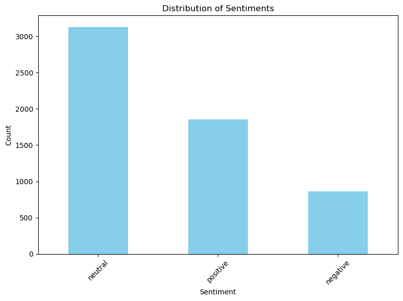

```python
# distribution plot
plt.figure(figsize=(8, 6))
sentiment_counts.plot(kind='bar', color='skyblue')
plt.title('Distribution of Sentiments')
plt.xlabel('Sentiment')
plt.ylabel('Count')
plt.xticks(rotation=45)
plt.tight_layout()
plt.show()
```

## Preprocessing Text Data

Before feeding our data into a machine learning model, we need to clean and preprocess it. This involves several steps:

- Tokenization: Splitting the text into individual words.
- Lowercasing: Converting all characters to lowercase to maintain uniformity.
- Removing punctuation: Punctuation does not contribute to sentiment and is removed.
- Removing stopwords: Common words like "and", "the", etc., that do not carry significant meaning for analysis are removed.

We'll create a function that encompasses all these preprocessing steps and apply it to our dataset.

```python
import pandas as pd
import string
from nltk import word_tokenize
from nltk.corpus import stopwords
import nltk

'''
# Download the necessary NLTK resources if required
nltk.download('punkt')
nltk.download('stopwords')
'''

# Function to preprocess text
def preprocess_text(text):
    # Tokenize the text
    tokens = word_tokenize(text)
    # Convert to lowercase
    tokens = [word.lower() for word in tokens]
    # Remove punctuation
    tokens = [word for word in tokens if word not in string.punctuation]
    # Define English stopwords
    stop_words = set(stopwords.words('english'))
    # Remove stopwords
    tokens = [word for word in tokens if word not in stop_words]
    # Join tokens back into string
    return " ".join(tokens)

# Assuming data is already loaded into 'data' DataFrame
# and that there is a column named 'Sentence' to process
data['Processed_Text'] = data['Sentence'].apply(preprocess_text)

# Drop the original 'Sentence' column if it's no longer needed
data.drop(columns=['Sentence'], inplace=True)

# Save the cleaned data to a new CSV file
data.to_csv('cleaned_dataset.csv', index=False)
```

```python
'''
nltk.download('wordnet')
'''


def text_transformation(df_col):
    corpus = []
    lm = WordNetLemmatizer()
    for item in df_col:
        new_item = re.sub('[^a-zA-Z]', ' ', str(item))
        new_item = new_item.lower()
        new_item = new_item.split()
        new_item = [lm.lemmatize(word) for word in new_item if word not in set(stopwords.words('english'))]
        corpus.append(' '.join(str(x) for x in new_item))
    return corpus

# Apply the preprocessing to the Sentence column
corpus = text_transformation(data['Processed_Text'])
```

## Visualizing Key Terms with Word Cloud

Following text preprocessing, we utilize a Word Cloud to visualize the most frequent and significant words in our corpus. A Word Cloud is a visual representation where the size of each word indicates its frequency or importance in the dataset.

The generated Word Cloud here reveals several key observations:

- Large words like "company," "market," "service," and "business" indicate these are common and potentially influential terms in the financial statements.
- The presence of currency terms like "eur" and "million" highlights discussions around financial figures.
- We also notice industry-specific terms such as "sale," "product," and "profit," which are typical in financial discourse.

This visualization helps us quickly identify the themes and terms that are prominent in the financial statements, providing insights into the focus areas of the reports and possibly correlating with market sentiment and business performance.

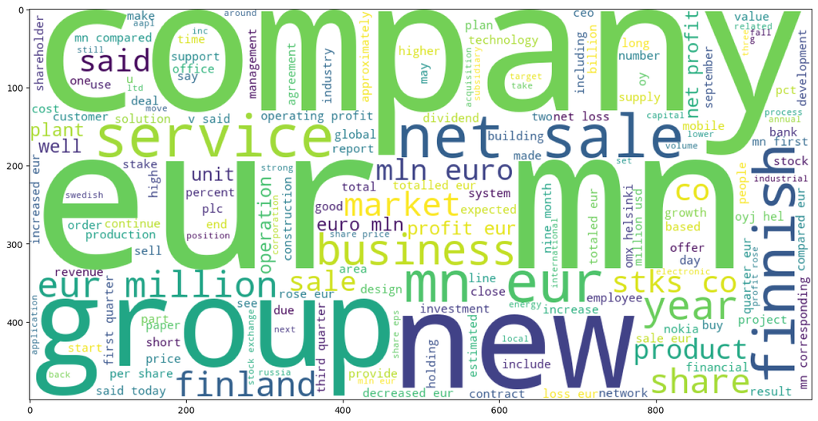

```python
from pylab import rcParams

rcParams['figure.figsize'] = 20,8
word_cloud = ""
for row in corpus:
    for word in row:
        word_cloud+=" ".join(word)
wordcloud = WordCloud(width = 1000, height = 500,background_color ='white',min_font_size = 10).generate(word_cloud)
plt.imshow(wordcloud)
```

## SVM Model Analysis

### Implementing Support Vector Machines for Sentiment Classification

Support Vector Machines (SVM) are a powerful machine learning model that has garnered wide usage for its robustness and effectiveness, particularly in the classification of data into distinct categories. The core idea behind SVM is to determine the optimal hyperplane which maximizes the margin between different classes of data points.

In the realm of sentiment analysis, SVMs are highly regarded for their proficiency in categorizing textual documents by sentiment. By leveraging SVM, we can discern and classify the underlying sentiments expressed in text documents, such as financial statements, into positive, negative, or neutral categories. This classification is achieved through the analysis of complex text features, converting subjective text data into quantifiable insights.

### Feature Engineering for Sentiment Analysis

After preprocessing the text, we need to convert the textual data into a format that machine learning algorithms can work with. This is called feature extraction. We will use TF-IDF (Term Frequency-Inverse Document Frequency) to transform our text data into numerical vectors.

- `TfidfVectorizer`: Converts a collection of raw documents to a matrix of TF-IDF features.

```python
# Feature extraction

from sklearn.model_selection import train_test_split
from sklearn.feature_extraction.text import TfidfVectorizer

vectorizer = TfidfVectorizer()
X = vectorizer.fit_transform(data['Processed_Text'])
y = data['Sentiment']
```

### Training Machine Learning Models for Sentiment Classification

With our features ready, we can now split our data into training and testing sets and begin training machine learning models.

- `train_test_split`: Function for splitting data arrays into two subsets: for training data and for testing data.
- `SVC`: The Support Vector Classifier from Scikit-learn’s SVM module, used here due to its effectiveness with high-dimensional data.

```python
# Split dataset into training and testing sets
X_train, X_test, y_train, y_test = train_test_split(X, y, test_size=0.2, random_state=42)
```

```python
from sklearn.svm import SVC
# Build and train the model
svm_model = SVC(kernel='linear')
svm_model.fit(X_train, y_train)
```

```
SVC(kernel='linear')
```

### Evaluating the Performance of the Sentiment Analysis Model

Evaluating the model's performance is critical to understanding how well our model will perform on unseen data. We will evaluate the SVM model using various performance metrics.

- `classification_report`: This function builds a text report showing the main classification metrics.

Upon training our SVM model, it's critical to evaluate its performance to ensure that it is making accurate predictions. The classification report generated from the `sklearn.metrics` module provides us with several key metrics:

- **Precision**: Indicates the proportion of positive identifications that were actually correct. For instance, when the model predicts the sentiment as negative, it is correct about 42% of the time.
- **Recall**: Also known as sensitivity, it measures the proportion of actual positives that were identified correctly. For example, the model correctly identifies 92% of all actual neutral sentiments.
- **F1-Score**: A weighted harmonic mean of precision and recall which balances the two metrics, especially in cases of uneven class distribution. A higher F1-score indicates a more robust model.
- **Support**: The number of actual occurrences of each class in the dataset, which helps us understand the balance of classes within the test data.

Here's a breakdown of our SVM model's performance:

- For the **negative** class, the model has low precision and recall, suggesting a difficulty in accurately classifying negative sentiments.
- The **neutral** class shows high recall but moderate precision, indicating that while most neutral sentiments are identified, there are also some false positives.
- The **positive** class has a relatively high precision, meaning that when a positive sentiment is predicted, it is likely to be correct.

The overall accuracy of the model stands at 71%, indicating that it correctly predicts the sentiment 71% of the time across all classes.

These metrics highlight areas where the model performs well and where there might be room for improvement. For instance, enhancing the model's ability to distinguish negative sentiments could be a focus for further tuning.

```python
from sklearn.metrics import classification_report
# Evaluate the model
y_pred = svm_model.predict(X_test)
print(classification_report(y_test, y_pred))
```

```
              precision    recall  f1-score   support

    negative       0.42      0.13      0.20       175
     neutral       0.70      0.92      0.79       622
    positive       0.78      0.62      0.69       372

    accuracy                           0.71      1169
   macro avg       0.63      0.56      0.56      1169
weighted avg       0.68      0.71      0.67      1169
```

### Applying the SVM Model to Unseen Data

Once the SVM model has been trained and evaluated, the next step is to see how it performs on new, unseen data. The ability to accurately predict sentiment on new statements is crucial for the model's practical application.

Here's how we approach this task:

1. **Defining New Sentences**: We create a list of new sentences that we wish to classify. These sentences are meant to mimic real-world data that the model would encounter.
2. **Preprocessing**: As with our training data, we preprocess these new sentences to match the format expected by our model. This step ensures consistency and improves the model's ability to make accurate predictions.
3. **Vectorization**: The preprocessed text is then transformed into numerical vectors using the same vectorizer object that was fitted on our training data.
4. **Prediction**: Finally, we pass these vectors into our SVM model to predict the sentiment. This step outputs the model's sentiment classification for each new sentence.

The results from the predictions are:

- The sentence "Corporate earnings have surpassed expectations, leading to a rally in the tech sector." is classified as **'positive'**.
- The sentence "The stock market is experiencing a growth." is also classified as **'positive'**.

Both sentences have been associated with a positive sentiment by our SVM model, reflecting the optimistic language within the text. This suggests that our model is capable of identifying and interpreting positive cues in financial discourse.

This demonstration showcases the model's potential in analyzing sentiment trends from textual data and its application in financial analysis, market monitoring, and decision-making processes.

```python
# Predict sentiment for new data
new_sentences = ["Corporate earnings have surpassed expectations, leading to a rally in the tech sector.",
                 "The stock market is experiencing a growth."]
new_sentences_processed = [preprocess_text(sentence) for sentence in new_sentences]
new_X = vectorizer.transform(new_sentences_processed)
new_predictions = svm_model.predict(new_X)
print("Predictions for new sentences:", new_predictions)
```

```
Predictions for new sentences: ['positive' 'positive']
```

## Using Naive Bayes Classifier

### Utilizing Naive Bayes for Sentiment Classification

The Naive Bayes classifier is another widely-used algorithm in machine learning, particularly known for its simplicity and effectiveness in text classification tasks. Based on Bayes' theorem, the Naive Bayes classifier assumes independence between predictors and calculates the probability of each class based on the presence of features in the given data.

In the context of sentiment analysis, Naive Bayes can swiftly categorize text documents as expressing positive, negative, or neutral sentiments based on the probability of words appearing in documents with known sentiments. This probabilistic model is especially efficient with large datasets and has proven to be remarkably successful in preliminary analyses where a quick and robust baseline is required.

With our textual data already preprocessed, vectorized, and ready from the SVM stage, we can apply the same preparation steps to feed the data into the Naive Bayes classifier. The expectation is that Naive Bayes will handle our sentiment analysis task with a high degree of accuracy, despite the simplifying assumptions it makes about feature independence.

```python
from sklearn.naive_bayes import MultinomialNB
```

```python
# Split dataset into training and testing sets
X_train, X_test, y_train, y_test = train_test_split(X, y, test_size=0.2, random_state=0)
```

```python
# Build and train the Naive Bayes model
nb_model = MultinomialNB()
nb_model.fit(X_train, y_train)
```

```
MultinomialNB()
```

### Evaluating Naive Bayes Classifier Performance

After training the Naive Bayes classifier with our financial sentiment data, we conduct an evaluation similar to the one we performed for the SVM model. We rely on metrics such as precision, recall, and F1-score to gauge the performance of our Naive Bayes model.

Given its probabilistic nature, the Naive Bayes classifier may excel in certain areas where SVM had shortcomings. For instance, it might better handle imbalanced data or be more efficient with a large set of features, due to its assumption of feature independence and its inherent speed in making predictions.

The resulting classification report will provide insights into how well the Naive Bayes model can differentiate between the various sentiments expressed in the financial statements. It will help us understand the model's strengths and limitations and may suggest areas for potential improvement or further fine-tuning.

### Naive Bayes Classifier Results Analysis

The classification report for the Naive Bayes model gives us a detailed view of its performance across the different sentiment classes:

- **Precision** is a measure of the accuracy of the positive predictions. Our model has a high precision for the negative class (0.86), meaning it is particularly reliable when it predicts a negative sentiment.
- **Recall** indicates the ability of the model to find all the positive instances. For the neutral class, the recall is extremely high (0.98), suggesting that the model is excellent at identifying neutral sentiments.
- The **F1-score** provides a balance between precision and recall. We see that the model has a high F1-score for the neutral class (0.79) but is lower for the positive class (0.54), which indicates there’s a trade-off between precision and recall for this particular sentiment.
- The **support** number shows how many occurrences there are in each class. This helps us understand the weight of each class in the evaluation.

Overall, the model has an **accuracy of 0.67**, which means it correctly predicts the sentiment 67% of the time.

When interpreting the macro and weighted averages:

- The **macro average** treats all classes equally, averaging the metric scores without considering the support. This is useful when you want to know how well the model performs across all classes.
- The **weighted average** takes the support into account, giving more weight to the classes with more instances.

```python
# Evaluate the model
y_pred = nb_model.predict(X_test)
print(classification_report(y_test, y_pred))
```

```
              precision    recall  f1-score   support

    negative       0.86      0.03      0.06       192
     neutral       0.66      0.98      0.79       643
    positive       0.70      0.44      0.54       334

    accuracy                           0.67      1169
   macro avg       0.74      0.48      0.46      1169
weighted avg       0.70      0.67      0.60      1169
```

### Applying the Naive Bayes Classifier to Unseen Data

We'll do the same process we did for SVM and get to know that how accurate this model is compared to SVM considering same data.

```python
# Predict sentiment for new data
new_sentences = ["Corporate earnings have surpassed expectations, leading to a rally in the tech sector.",
                 "The stock market is experiencing a growth."]
new_sentences_processed = [preprocess_text(sentence) for sentence in new_sentences]
new_X = vectorizer.transform(new_sentences_processed)
new_predictions = nb_model.predict(new_X)
print("Predictions for new sentences:", new_predictions)
```

```
Predictions for new sentences: ['positive' 'positive']
```

## Random Forest Classifier

### Leveraging Random Forest for Enhanced Sentiment Classification

The Random Forest algorithm is an ensemble learning method known for its high accuracy, robustness, and ease of use. It operates by constructing a multitude of decision trees at training time and outputting the class that is the mode of the classes (classification) of the individual trees.

Random Forest is particularly well-suited for sentiment analysis due to its ability to handle large datasets with numerous features and its capacity for managing overfitting. Each decision tree in the forest considers a random subset of features when forming its splits, leading to a diversity that generally results in a more comprehensive model.

In our sentiment analysis task, Random Forest can capture the complexity and subtleties of language by taking into account the multitude of contextual clues found in text. By analyzing a wide array of features derived from the text, Random Forest can often discern nuanced differences between sentiments that might be missed by simpler models.

We will proceed by feeding the preprocessed and vectorized text data into the Random Forest classifier and then evaluate its performance, looking to see if this more complex approach can outperform other models we've tested like SVM and Naive Bayes.

```python
from sklearn.ensemble import RandomForestClassifier
```

```python
# Feature extraction
vectorizer = TfidfVectorizer()
X = vectorizer.fit_transform(data['Processed_Text'])
y = data['Sentiment']
```

```python
# Split dataset into training and testing sets
X_train, X_test, y_train, y_test = train_test_split(X, y, test_size=0.2, random_state=0)
```

```python
# Build and train the Random Forest model
rf_model = RandomForestClassifier(n_estimators=100, random_state=0)
rf_model.fit(X_train, y_train)
```

```
RandomForestClassifier(random_state=0)
```

### Analysis of Random Forest Classifier Results

The classification report provides a snapshot of the Random Forest model's performance on the test set. Here's what the metrics indicate about the model's ability to classify sentiments:

- **Precision**: This metric reflects the ratio of correctly predicted positive observations to the total predicted positive observations. The precision for negative sentiments is notably low at 0.15, suggesting that the model often incorrectly labels other sentiments as negative.
- **Recall**: Also known as the true positive rate, it measures how many actual positives were correctly identified. The recall is highest for neutral sentiments at 0.83, indicating that the model is quite adept at identifying neutral sentiments in the data.
- **F1-Score**: A weighted average of precision and recall, the F1-score is particularly useful when the class distribution is uneven. The model scores highest in the neutral category (0.74), which is consistent with the recall rate.
- **Support**: This number shows how many actual cases of each class exist in the dataset. Here, we have 192 negative, 643 neutral, and 334 positive instances.

The overall **accuracy** of the model stands at 0.64, meaning it accurately predicts the sentiment 64% of the time. However, the macro and weighted averages of precision, recall, and F1-score reveal that the model's performance is uneven across the different classes. While it performs well for neutral and positive classes, its ability to correctly identify negative sentiments is lacking. This could be due to a variety of factors, such as an imbalance in the dataset or the model's sensitivity to the features that distinguish negative sentiments.

The weighted average gives us insight into the model's performance across all classes, taking the number of instances into account. With a weighted average F1-score of 0.61, it suggests that while the model is fairly accurate on average, there may be room for improvement, particularly in correctly identifying negative sentiments without compromising the performance on other classes.

Moving forward, strategies such as rebalancing the dataset, feature engineering, or hyperparameter tuning could be considered to enhance the model's predictive accuracy, especially for the underperforming classes.

```python
# Evaluate the model
y_pred = rf_model.predict(X_test)
print(classification_report(y_test, y_pred))
```

```
              precision    recall  f1-score   support

    negative       0.15      0.08      0.10       192
     neutral       0.67      0.83      0.74       643
    positive       0.73      0.60      0.66       334

    accuracy                           0.64      1169
   macro avg       0.52      0.50      0.50      1169
weighted avg       0.60      0.64      0.61      1169
```

### Applying the Random Forest Classifier to Unseen Data

We'll do the same process we did for SVM and get to know that how accurate this model is compared to SVM and Naive Bayes Classifier considering same data.

```python
# Predict sentiment for new data
new_sentences = ["Corporate earnings have surpassed expectations, leading to a rally in the tech sector.",
                 "The stock market is experiencing a growth."]
new_sentences_processed = [preprocess_text(sentence) for sentence in new_sentences]
new_X = vectorizer.transform(new_sentences_processed)
new_predictions = rf_model.predict(new_X)
print("Predictions for new sentences:", new_predictions)
```

```
Predictions for new sentences: ['positive' 'positive']
```

## Identifying Key Financial Terms with Frequency Analysis

To gain further insights from our sentiment analysis, we conduct a frequency analysis of specific financial terms within the dataset. This allows us to see which financial concepts are most prevalent and could potentially influence market sentiment and trends.

### Process Overview

1. **Selection of Financial Terms**: We begin by defining a list of financial terms that are of interest to us, such as 'dividend', 'earnings', 'inflation', 'stock', and so on. These terms are representative of key financial concepts that can impact sentiment analysis.
2. **Data Preparation**: We convert all these terms to lowercase to ensure consistency during the matching process, as text data often contains a mix of uppercase and lowercase letters.
3. **Filtering the Dataset**: Our dataset is filtered to include only those sentences that contain our predefined financial terms. This is done by scanning through the 'Processed_Text' column in our data, looking for the presence of these terms.
4. **Counting Term Frequencies**: We use Python's `Counter` from the collections module to tally how often each financial term appears. This provides us with a raw count of occurrences for each term.
5. **Extracting Top Terms**: We then extract the most common financial terms along with their counts and convert this data into a format suitable for analysis and visualization (e.g., lists or a DataFrame).

### Visualization

The bar chart below displays the top 5 financial terms found in the dataset. The x-axis represents the financial terms, and the y-axis indicates the frequency of each term.

This analysis helps us quickly identify the financial concepts that are most commonly discussed, which can be invaluable for a variety of analyses, such as sentiment analysis, trend analysis, or thematic investigation in the context of financial markets and entities.

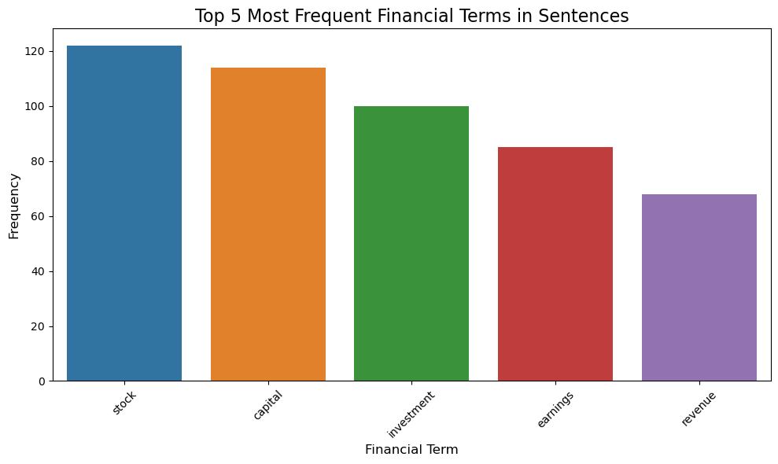

```python
'''
This approach allows financial analysts to quickly identify key financial concepts that are most frequently discussed in the dataset,
which could be valuable for a variety of analyses, such as sentiment analysis, trend analysis, or thematic
investigation in the context of financial markets and entities.

'''

import pandas as pd
from collections import Counter
import matplotlib.pyplot as plt
import seaborn as sns


# Define a list of financial terms you are interested in
financial_terms = [
    'dividend', 'earnings', 'inflation', 'stock', 'bond',
    'commodity', 'derivative', 'investment', 'capital', 'revenue',
    # ... more financial terms ...
]

# Lowercase the financial terms for matching purposes
financial_terms = set(map(str.lower, financial_terms))

# Filter sentences to only include these financial terms
# We use word.lower() to match case insensitively
financial_terms_counts = Counter(
    word for sentence in data['Processed_Text']
    for word in sentence.lower().split() if word in financial_terms
)

# Get the most common financial terms in the dataset
most_common_financial_terms = financial_terms_counts.most_common()

# Extract terms and their counts into separate lists
terms, term_counts = zip(*most_common_financial_terms)

# Create a DataFrame for the most common financial terms
most_common_terms_df = pd.DataFrame({'Term': terms, 'Count': term_counts})

# Create a bar plot for the most common financial terms
plt.figure(figsize=(10, 6))
ax = sns.barplot(x='Term', y='Count', data=most_common_terms_df.head(5))  # top 5 terms

# Set title and labels for axes
ax.set_title('Top 5 Most Frequent Financial Terms in Sentences', fontsize=16)
ax.set_xlabel('Financial Term', fontsize=12)
ax.set_ylabel('Frequency', fontsize=12)

# Show the plot
plt.xticks(rotation=45)  # Rotate x-axis labels for better readability
plt.tight_layout()  # Adjust layout
plt.show()
```

## Understanding the Confusion Matrix of Our Model

A confusion matrix is a powerful tool for summarizing the performance of a classification algorithm. The matrix makes it easy to see whether the system is confusing two classes (i.e., commonly mislabeling one as another).

In our confusion matrix:

- The **rows** represent the actual classes, sometimes referred to as the "True label".
- The **columns** represent the predicted classes, sometimes referred to as the "Predicted label".

For our sentiment analysis model, we have:

- **True Negatives (Top-Left)**: The number of correctly predicted negative sentiments.
- **False Positives (Top-Middle)**: The number of times negative sentiments were incorrectly predicted as neutral.
- **False Positives (Top-Right)**: The number of times negative sentiments were incorrectly predicted as positive.
- **False Negatives (Center-Left)**: The number of times neutral sentiments were incorrectly predicted as negative.
- **True Positives (Center-Middle)**: The number of correctly predicted neutral sentiments.
- **False Positives (Center-Right)**: The number of times neutral sentiments were incorrectly predicted as positive.
- **False Negatives (Bottom-Left)**: The number of times positive sentiments were incorrectly predicted as negative.
- **False Negatives (Bottom-Middle)**: The number of times positive sentiments were incorrectly predicted as neutral.
- **True Positives (Bottom-Right)**: The number of correctly predicted positive sentiments.

For example, we can see from the matrix that our model has a strong ability to correctly identify neutral sentiments, but it appears to struggle with correctly classifying negative sentiments, as indicated by the higher number of false positives for the negative class. Similarly, positive sentiments are also often confused with neutral, shown by the false negatives for the positive class.

This visual representation helps us quickly identify the most common errors the model is making, which is invaluable for refining the model to improve its predictive accuracy.

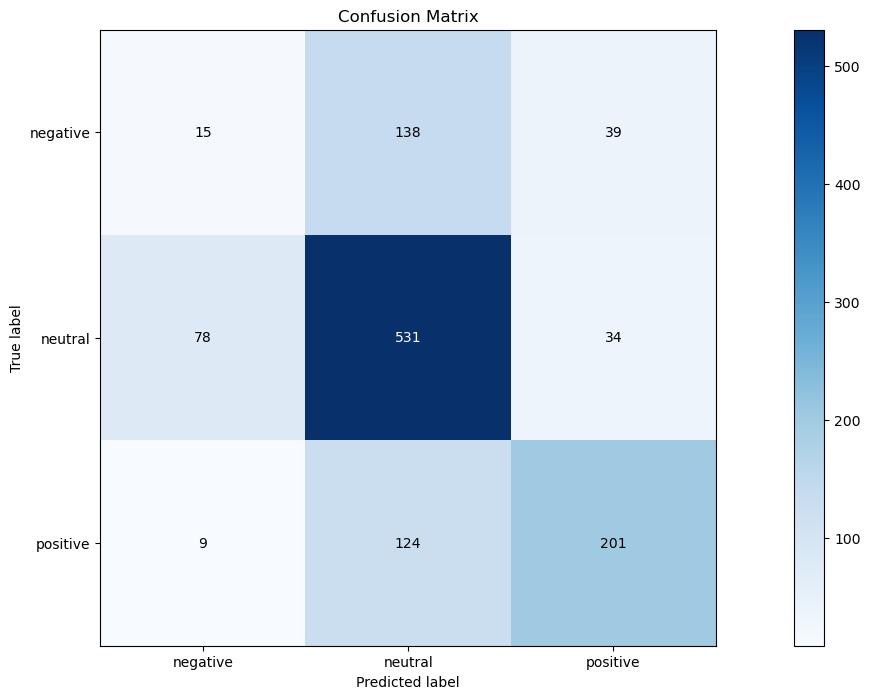

```python
# Confusion matrix
conf_matrix = confusion_matrix(y_test, y_pred)

# Plot the confusion matrix using scikitplot
plot_confusion_matrix(y_test, y_pred)
plt.show()
```

## ROC Curve and Model Performance

The ROC (Receiver Operating Characteristic) curve is an essential tool for evaluating the performance of a binary classifier. It plots the True Positive Rate (TPR) against the False Positive Rate (FPR) at various threshold settings.

### Constructing the ROC Curve

To construct the ROC curve, we follow these steps in our code:

1. **Data Preparation**: We encode our target labels into a binary format, suitable for binary classification, and then vectorize our processed text data for the model to understand it.
2. **Model Training**: We train a Logistic Regression model, which is a suitable algorithm for binary classification problems. Logistic Regression works by predicting the probability that a given data entry belongs to the category marked '1'.
3. **Probability Estimates**: Instead of just predicting a label for each test instance, we use our model to estimate probabilities. Specifically, we're interested in the probability that each instance is positive (e.g., has the sentiment 'positive').
4. **ROC and AUC Calculation**: We then calculate the ROC curve and the Area Under the Curve (AUC) score. The AUC score is a single scalar value that summarizes the performance of the classifier across all thresholds. A value of 1 indicates a perfect classifier, while a value of 0.5 suggests no discriminative power.

### Interpreting the ROC Curve

The ROC curve in the plot below illustrates our model's performance:

- The x-axis represents the False Positive Rate (FPR), the rate at which the model wrongly predicts positive for the negative class.
- The y-axis represents the True Positive Rate (TPR), the rate at which the model correctly predicts positive for the positive class.
- The dashed line represents a completely random classifier; a good classifier stays as far away from that line as possible (toward the top-left corner).

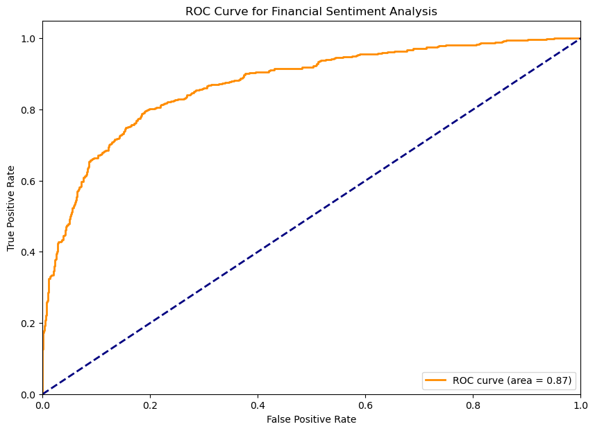

```python
from sklearn.model_selection import train_test_split
from sklearn.preprocessing import LabelEncoder
from sklearn.feature_extraction.text import CountVectorizer
from sklearn.linear_model import LogisticRegression
from sklearn.metrics import roc_curve, auc
import matplotlib.pyplot as plt

# Encode the sentiments
label_encoder = LabelEncoder()
data['Binary_Sentiment'] = label_encoder.fit_transform(data['Sentiment'] == 'positive')

# Text vectorization
vectorizer = CountVectorizer()
X = vectorizer.fit_transform(data['Processed_Text'])
y = data['Binary_Sentiment']

# Splitting the data into training and testing sets
X_train, X_test, y_train, y_test = train_test_split(X, y, test_size=0.3, random_state=42)

# Train a Logistic Regression model
model = LogisticRegression(max_iter=1000)
model.fit(X_train, y_train)

# Predict probabilities
y_proba = model.predict_proba(X_test)[:, 1]

# Calculate ROC curve and AUC
fpr, tpr, thresholds = roc_curve(y_test, y_proba)
roc_auc = auc(fpr, tpr)

# Plotting ROC Curve
plt.figure(figsize=(10, 7))
plt.plot(fpr, tpr, color='darkorange', lw=2, label='ROC curve (area = %0.2f)' % roc_auc)
plt.plot([0, 1], [0, 1], color='navy', lw=2, linestyle='--')
plt.xlim([0.0, 1.0])
plt.ylim([0.0, 1.05])
plt.xlabel('False Positive Rate')
plt.ylabel('True Positive Rate')
plt.title('ROC Curve for Financial Sentiment Analysis')
plt.legend(loc="lower right")
plt.show()
```